# MRI-Based Detection of Alzheimer’s Disease and Mild Cognitive Impairment

## Roni Tibon: Roni.Tibon@city.ac.uk

The code below applies multiple machine learning techniques to the BioFIND and ADNI datasets in order to classify individuals with mild cognitive impairment (MCI) and Alzheimer's disease against healthy controls.

# Import and Settings

```python
# Imports and Settings

import numpy as np
import pandas as pd
import pickle
import warnings
import random

import matplotlib.pyplot as plt
import seaborn as sns

#from imblearn.over_sampling import SMOTE

from sklearn.preprocessing import StandardScaler
from sklearn.utils import shuffle
from sklearn.model_selection import train_test_split, GridSearchCV
from sklearn.svm import SVC
from sklearn.metrics import plot_roc_curve
from sklearn import metrics
from sklearn.linear_model import LogisticRegression
from sklearn.tree import DecisionTreeClassifier
from sklearn import tree
from sklearn.neighbors import KNeighborsClassifier
from sklearn.discriminant_analysis import LinearDiscriminantAnalysis
from sklearn.naive_bayes import GaussianNB
from sklearn.ensemble import RandomForestClassifier

import torch
import torch.nn as nn
import torch.nn.functional as F

from skorch import NeuralNetClassifier
from skorch.callbacks import EarlyStopping

# Set display options for Pandas
pd.set_option('display.max_columns', 8)
pd.set_option('display.width', 1000)
pd.set_option('display.max_colwidth', None)

# Hide warnings
warnings.filterwarnings('ignore')
```

# Data Preperation

BioFIND and ADNI data

```python
# Read data

BioFIND_data = pd.read_csv('BioFIND_table.csv') # this file is avaliable in the submitted folder
ADNI_data = pd.read_csv('ADNI_table.csv') # this file is avaliable in the submitted folder

# Read DKT data (Appendix 3)
#BioFIND_data = pd.read_csv('BioFIND_table_DKT.csv') # this file is avaliable in the submitted folder
#ADNI_data = pd.read_csv('ADNI_table_DKT.csv') # this file is avaliable in the submitted folder

# standardize the features (Appendix 4)
#scaler = StandardScaler()
#BioFIND_data.iloc[:,0:30] = scaler.fit_transform(BioFIND_data.iloc[:,0:30])
#ADNI_data.iloc[:,0:30] = scaler.fit_transform(ADNI_data.iloc[:,0:30])

print(BioFIND_data.describe())
print(ADNI_data.describe())
```

```
       L_G_and_S_cingul-Mid-Post  L_G_cingul-Post-dorsal  L_G_insular_short  L_G_oc-temp_lat-fusifor  ...  hippocampus    amygdala   accumbens       Class
count                 307.000000              307.000000         307.000000               307.000000  ...   307.000000  307.000000  307.000000  307.000000
mean                    1.964813                1.845529           1.931922                 2.019890  ...     2.054980    1.943444    1.714061    0.462541
std                     0.032017                0.044140           0.037104                 0.039837  ...     0.034530    0.046792    0.055056    0.499409
min                     1.830345                1.590157           1.602608                 1.877893  ...     1.926166    1.727991    1.465904    0.000000
25%                     1.947578                1.824199           1.912735                 1.998256  ...     2.039119    1.919062    1.680353    0.000000
50%                     1.966975                1.849745           1.933726                 2.018691  ...     2.062017    1.950851    1.718001    0.000000
75%                     1.986864                1.875282           1.955112                 2.046292  ...     2.077155    1.974256    1.751084    1.000000
max                     2.042950                1.944368           2.014191                 2.118581  ...     2.133695    2.034655    1.843744    1.000000

[8 rows x 31 columns]
       L_G_and_S_cingul-Mid-Post  L_G_cingul-Post-dorsal  L_G_insular_short  L_G_oc-temp_lat-fusifor  ...  hippocampus    amygdala   accumbens       Class
count                 152.000000              152.000000         152.000000               152.000000  ...   152.000000  152.000000  152.000000  152.000000
mean                    1.964001                1.850453           1.928683                 2.026905  ...     2.041216    1.936877    1.722778    0.690789
std                     0.032606                0.036925           0.031389                 0.037899  ...     0.035637    0.056174    0.058733    0.463696
min                     1.789964                1.754649           1.830854                 1.924880  ...     1.923251    1.770078    1.575446    0.000000
25%                     1.947032                1.824131           1.909076                 2.003781  ...     2.018993    1.905104    1.682701    0.000000
50%                     1.964471                1.850106           1.928298                 2.026826  ...     2.042607    1.944351    1.723467    1.000000
75%                     1.987155                1.874904           1.946901                 2.053817  ...     2.069167    1.978086    1.764570    1.000000
max                     2.031100                1.949515           2.007891                 2.113063  ...     2.107793    2.044010    1.875166    1.000000

[8 rows x 31 columns]
```

# View and Plot Preprocessed Data

Plot Histograms with density plots, boxplots, and correlation matrix. This code produces Figure 1 in the paper.

```
BioFIND info:
total number of cases:  307
number of Patient cases (MCI):  142
number of Ctrl cases:  165
--------------------------------------------
ADNI info:
total number of cases:  152
number of Patient cases (MCI+AD):  105
number of Ctrl cases:  47
--------------------------------------------
```

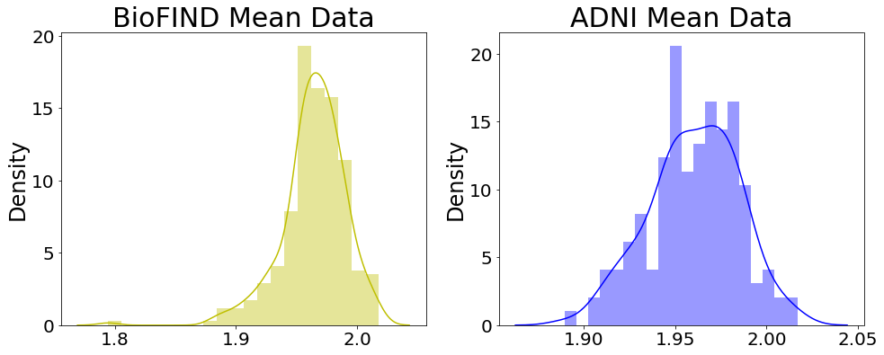

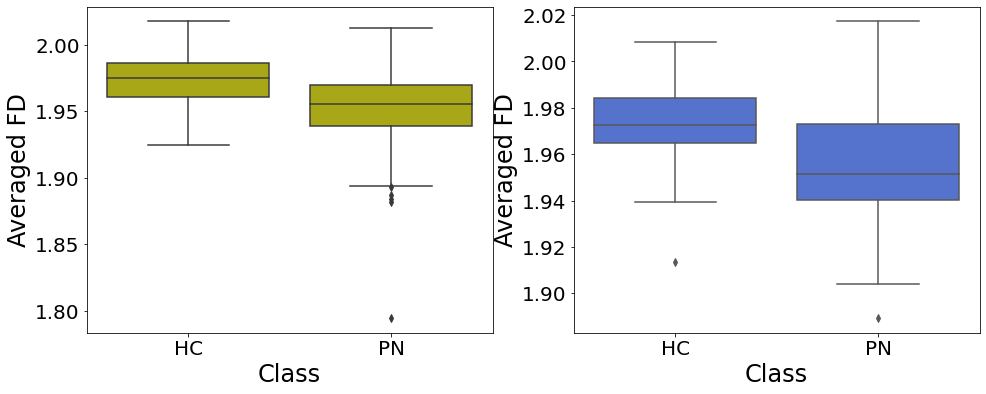

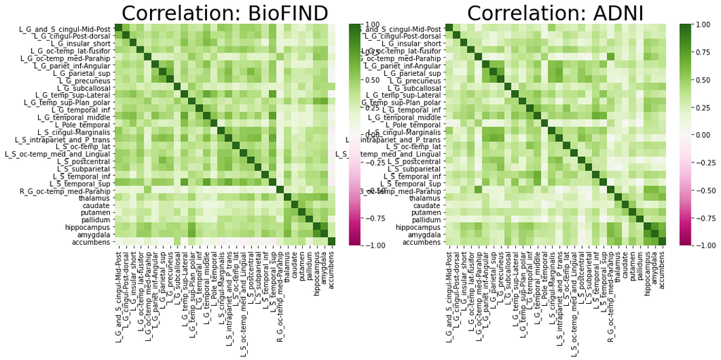

```python
# View data

print("BioFIND info:")
print("total number of cases: ", len(BioFIND_data))
print("number of Patient cases (MCI): ", len(BioFIND_data[BioFIND_data['Class']==1]))
print("number of Ctrl cases: ", len(BioFIND_data[BioFIND_data['Class']==0]))
print("--------------------------------------------")
print("ADNI info:")
print("total number of cases: ", len(ADNI_data))
print("number of Patient cases (MCI+AD): ", len(ADNI_data[ADNI_data['Class']==1]))
print("number of Ctrl cases: ", len(ADNI_data[ADNI_data['Class']==0]))
print("--------------------------------------------")

# Histograms

BioFIND_data['avg'] = BioFIND_data.iloc[:,0:30].mean(axis=1)
ADNI_data['avg'] = ADNI_data.iloc[:,0:30].mean(axis=1)

f, axes = plt.subplots(1, 2, figsize=(16,6))
sns.distplot(BioFIND_data['avg'], color='y', ax=axes[0], axlabel=False, bins=20).set_title("BioFIND Mean Data", fontsize=30)
sns.distplot(ADNI_data['avg'], color='b', ax=axes[1], axlabel=False, bins=20).set_title("ADNI Mean Data", fontsize=30)
axes[0].tick_params(axis='x', labelsize=20); axes[1].tick_params(axis='x', labelsize=20)
axes[0].tick_params(axis='y', labelsize=20); axes[1].tick_params(axis='y', labelsize=20)
axes[0].set_ylabel("Density", fontsize=24); axes[1].set_ylabel("Density", fontsize=24);
plt.show()

# Boxplots

f, axes = plt.subplots(1, 2, figsize=(16,6))
sns.boxplot(x="Class", y="avg", data=BioFIND_data, ax=axes[0], color='y')#.set_title("BioFIND", fontsize=30)
sns.boxplot(x="Class", y="avg", data=ADNI_data, ax=axes[1], color='royalblue')#.set_title("ADNI", fontsize=30)
axes[0].tick_params(axis='x', labelsize=20); axes[1].tick_params(axis='x', labelsize=20)
axes[0].tick_params(axis='y', labelsize=20); axes[1].tick_params(axis='y', labelsize=20)
axes[0].set_xlabel("Class", fontsize=24); axes[1].set_xlabel("Class", fontsize=24);
axes[0].set_ylabel("Averaged FD", fontsize=24); axes[1].set_ylabel("Averaged FD", fontsize=24);
axes[0].set_xticks([0,1]); axes[0].set_xticklabels(['HC','PN'], fontsize=20)
axes[1].set_xticks([0,1]); axes[1].set_xticklabels(['HC','PN'], fontsize=20)
plt.show()

# Plot correlation matrix

f, axes = plt.subplots(1, 2, figsize=(16,6))
sns.heatmap(BioFIND_data.iloc[:,0:30].corr(), ax=axes[0], cmap='PiYG', center=0, vmin=-1, vmax=1).set_title("Correlation: BioFIND", fontsize=30)
sns.heatmap(ADNI_data.iloc[:,0:30].corr(), ax=axes[1], cmap='PiYG', center=0, vmin=-1, vmax=1).set_title("Correlation: ADNI", fontsize=30)
plt.show()
```

# Define Sets

```python
# Define "X" and "y": Train in BioFIND and test on ADNI

X_train = BioFIND_data.iloc[:,0:30]
y_train = BioFIND_data.iloc[:,30]

X_test = ADNI_data.iloc[:,0:30]
y_test = ADNI_data.iloc[:,30]

# Change type

X_train = np.float32(X_train)
X_test = np.float32(X_test)

y_train = np.int64(y_train)
y_test = np.int64(y_test)
```

# Define Functions and Classes

## Define MLP Network

Before classification can be done with MLP, the network needs to be defined

```python
torch.manual_seed(0)
```

```
<torch._C.Generator at 0x1cf5df72558>
```

```python
# #%%writefile ClassifierMLP.py # uncomment to recreate the ClassifierMLP.py file. This file is also avaliable in the submitted folder.

import torch.nn as nn
import torch.nn.functional as F

# Define the class for the network
class ClassifierMLP(nn.Module):
     def __init__(self, num_units=10, dropout=0.0, nonlin=F.relu): # these will vary based on the grid search
         super(ClassifierMLP, self).__init__()

         self.dropout = nn.Dropout(dropout)    # always set to 0, following preliminary examination
         self.nonlin = nonlin                  # nonlinear activation is either relu or leaky_relu
         self.hidden = nn.Linear(30, num_units) # num unit is either 3 or 5
         self.output = nn.Linear(num_units, 2)

     def forward(self, X, **kwargs):
         X = self.nonlin(self.hidden(X))
         X = self.dropout(X)
         X = F.softmax(self.output(X), dim=-1)
         return X
```

```python
net = NeuralNetClassifier(
     ClassifierMLP,
     verbose = 0,
     max_epochs = 5,               # kept low to avoid overfitting
     callbacks = [EarlyStopping()], # apply early stopping
     iterator_train__shuffle=True,
     optimizer = torch.optim.SGD,   # SGD optimiser. Adam was also tested in preliminary examination
     optimizer__momentum=0.7        # avoid local minima
 )
```

## Plot Confusion Matrix

```python
def plot_conf(y_train, y_pred_train, y_test, y_pred_test, algo, cmap):

    confm_train = pd.crosstab(y_train, y_pred_train, margins = False, normalize='all')
    confm_test = pd.crosstab(y_test, y_pred_test, margins = False, normalize='all')

    f, axes = plt.subplots(1, 2, figsize=(12, 5), sharey=True)
    #f.suptitle(algo, fontsize=18)

    sns.heatmap(ax=axes[0], data=confm_train, cmap=cmap, annot=True, annot_kws={"fontsize":24}, vmin=0, vmax=1)
    axes[0].set_title('Train Set', fontsize=30)
    axes[0].set_xlabel("Predicted Class", fontsize=24); axes[0].set_ylabel("Actual Class", fontsize=24)
    axes[0].set_xticks([0.5,1.5]); axes[0].set_xticklabels(['HC','PN'], fontsize=20)
    axes[0].set_yticks([0.5,1.5]); axes[0].set_yticklabels(['HC','PN'], fontsize=20)
    sns.heatmap(ax=axes[1], data=confm_test, cmap=cmap, annot=True, annot_kws={"fontsize":24}, vmin=0, vmax=1)
    axes[1].set_title('Test Set', fontsize=30)
    axes[1].set_xlabel("Predicted Class", fontsize=24); axes[1].set_ylabel("Actual Class", fontsize=24)
    axes[1].set_xticks([0.5,1.5]); axes[1].set_xticklabels(['HC','PN'], fontsize=20)
    axes[1].set_yticks([0.5,1.5]); axes[1].set_yticklabels(['HC','PN'], fontsize=20)

    return None
```

## Plot ROC and AUC

```python
def plot_roc(estimator, algo, cmap):


    dt_disp_train = plot_roc_curve(estimator, X_train, y_train, C=cmap, linewidth=3)
    ax = plt.gca()
    dt_disp_test = plot_roc_curve(estimator, X_test, y_test, ax=ax, alpha=0.8, C=cmap, linestyle='--', linewidth=3)
    ax = plt.gca()
    #ax.title.set_text(algo)
    ax.title.set_text('ROC')
    ax.title.set_size(30)
    ax.tick_params(axis='x', labelsize=20); ax.tick_params(axis='y', labelsize=20)
    ax.set_xlabel("False Positive Rate", fontsize=24); ax.set_ylabel("True Positive Rate", fontsize=24)
    plt.style.use('default')

    return None
```

## Print accuracy, recall and precision

```python
def view_matrices(y_train, y_test, y_pred_train, y_pred_test, algo):

    print('\n-------------------\nMatrices for', algo, '\n-------------------')
    print('\nTRAINING\n')
    print('overall accuracy: ', "%.2f" % metrics.accuracy_score(y_train, y_pred_train))
    print('Ctrl recall: ', "%.2f" % metrics.recall_score(y_train, y_pred_train))
    print('Ctrl precision: ', "%.2f" % metrics.precision_score(y_train, y_pred_train))
    print('Ctrl F1 score: ', "%.2f" % metrics.f1_score(y_train, y_pred_train))
    print('MCI recall: ', "%.2f" % metrics.recall_score(y_train, y_pred_train, pos_label=0))
    print('MCI precision: ', "%.2f" % metrics.precision_score(y_train, y_pred_train, pos_label=0))
    print('MCI F1 score: ', "%.2f" % metrics.f1_score(y_train, y_pred_train, pos_label=0))

    print('\nTESTING\n')
    print('overall accuracy: ', "%.2f" % metrics.accuracy_score(y_test, y_pred_test))
    print('Ctrl recall: ', "%.2f" % metrics.recall_score(y_test, y_pred_test))
    print('Ctrl precision: ', "%.2f" % metrics.precision_score(y_test, y_pred_test))
    print('Ctrl F1 score: ', "%.2f" % metrics.f1_score(y_test, y_pred_test))
    print('MCI recall: ', "%.2f" % metrics.recall_score(y_test, y_pred_test, pos_label=0))
    print('MCI precision: ', "%.2f" % metrics.precision_score(y_test, y_pred_test, pos_label=0))
    print('MCI F1 score: ', "%.2f" % metrics.f1_score(y_test, y_pred_test, pos_label=0))

    return None
```

# Classification Algorithms

Eight classification algorithms were used. For each algorithm, grid search was performed across a range of values

## Decision Tree

Non-parametric supervised method. Decision rules are inferred from the data features

```python
# Define parameters for grid

param_grid = {'criterion':['gini','entropy','log_loss'], #function to measure the quality of a split
              'max_depth':[2,4,8,16,22,None], #maximum depth of the tree
              'min_samples_leaf':[1,5,20,40,80], #minimum number of samples required to be at a leaf node
              'max_features':[5,15,None]} #number of features to consider when looking for the best split

# Fit models

dt_g = GridSearchCV(DecisionTreeClassifier(), param_grid, refit=True, cv=10, scoring='accuracy', return_train_score=True)
dt_g.fit(X_train,y_train)

print("DT best model: \n", dt_g.best_estimator_, "\n")

# Save model: all models in the grid will be saved

path = "Models\DT_models_FDAD.pkl"
model = dt_g

with open(path, 'wb') as f:
    pickle.dump(model, f)
```

```
DT best model:
 DecisionTreeClassifier(max_depth=2, min_samples_leaf=20)
```

## K-Nearest neighbour

Supervised method that used for both classification and regression. Finds the distances between a query and all the examples in the data, selects the specified number examples (K) closest to the query, then votes for the most frequent label

```python
# Define parameters for grid

param_grid = {'n_neighbors':[2,3,5,10,20,40,80], #number of neighbors to use
              'metric':['minkowski','cosine','manhattan'], #metric to use for distance computation. when p=2 (default),'minkowski'=euclidean distance
              'algorithm':['ball_tree', 'kd_tree', 'brute']} #algorithm used to compute the nearest neighbors

# Fit models

knn_g = GridSearchCV(KNeighborsClassifier(), param_grid, refit=True, cv=10, scoring='accuracy', return_train_score=True)
knn_g.fit(X_train,y_train)

print("KNN best model: \n", knn_g.best_estimator_, "\n")

# Save model: all models in the grid will be saved

path = "Models\KNN_models_FDAD.pkl"
model = knn_g

with open(path, 'wb') as f:
    pickle.dump(model, f)
```

```
KNN best model:
 KNeighborsClassifier(algorithm='brute', metric='cosine', n_neighbors=2)
```

## Linear discriminant analysis

Makes predictions by estimating the probability that a new set of inputs belongs to each class. The class that gets the highest probability is the output class and a prediction is made. The model uses Bayes Theorem to estimate the probabilities

```python
# Define parameters for grid

param_grid = {'solver':['svd', 'lsqr', 'eigen'], #solver to compute log-posterior. svd does not compute a covariance matrix so cannot be used with shrinkage
              'shrinkage': ['auto', 0, 0.01, 0.02, 0.05, 0.2, 0.4, 0.8, None]} #regularization used to improve the estimation of covariance matrices in situations where the number of training samples is small compared to the number of features. works only with ‘lsqr’ and ‘eigen’ solvers

# Fit models

lda_g = GridSearchCV(LinearDiscriminantAnalysis(), param_grid, refit=True, cv=10, scoring='accuracy', return_train_score=True)
lda_g.fit(X_train,y_train)

print("LDA best model: \n", lda_g.best_estimator_, "\n")

# Save model: all models in the grid will be saved

path = "Models\LDA_models_FDAD.pkl"
model = lda_g

with open(path, 'wb') as f:
    pickle.dump(model, f)
```

```
LDA best model:
 LinearDiscriminantAnalysis(shrinkage='auto', solver='lsqr')
```

## Logistic Regression

Commonly used for binary output. Predicts the probability of occurrence of a binary event utilizing a logit function

```python
# Define parameters for grid

param_grid = {"C": np.logspace(start=1, stop=10), #inverse of regularization strength: smaller values specify stronger regularization
        "penalty": ["l1","l2","elasticnet"]} #l1 lasso l2 ridge

# Fit models

lg_g = GridSearchCV(LogisticRegression(), param_grid, refit=True, cv=10, scoring='accuracy', return_train_score=True)
lg_g.fit(X_train,y_train)

print("LG best model: \n", lg_g.best_estimator_, "\n")

# Save model: all models in the grid will be saved

path = "Models\LG_models_FDAD.pkl"
model = lg_g

with open(path, 'wb') as f:
    pickle.dump(model, f)
```

```
LG best model:
 LogisticRegression(C=82.86427728546842)
```

## Multilayer perceptron

Feedforward neural network, fully connected, with one hidden layer

```python
# Define parameters for grid

random.seed(103)

param_grid = {
    # hyperparameters:
    'lr': np.logspace(start=0.01, stop=0.5, num=10), #learning rate
    'batch_size': [16, 32, 64], #size of batch when slicing the data

    # module parameters:
    'module__num_units': [5, 10, 25, 40], #number of units in hidden layer
    'module__nonlin':[F.relu, F.leaky_relu] #function for nono
}

# Fit models

mlp_g = GridSearchCV(net, param_grid, refit=True, cv=10, scoring='accuracy', return_train_score=True)
mlp_g.fit(X_train, y_train)

print("MLP best model: \n", mlp_g.best_estimator_, "\n")

# Save model: all models in the grid will be saved

path = "Models\MLP_models_FDAD.pkl"
model = mlp_g

with open(path, 'wb') as f:
    pickle.dump(model, f)
```

[output not shown]

## Naïve Bayes

Supervised learning algorithms based on applying Bayes’ theorem with the “naive” assumption of conditional independence between every pair of features given the value of the class variable.

```python
# Define parameters for grid

param_grid = { 'var_smoothing': np.logspace(0,-3, num=50) } #portion of the largest variance of all features that is added to variances for calculation stability

# Fit models

nb_g = GridSearchCV(GaussianNB(), param_grid, refit=True, cv=10, scoring='accuracy', return_train_score=True)
nb_g.fit(X_train,y_train)

print("NB best model: \n", nb_g.best_estimator_, "\n")

# Save model: all models in the grid will be saved

path = "Models\\NB_models_FDAD.pkl"
model = nb_g

with open(path, 'wb') as f:
    pickle.dump(model, f)
```

```
NB best model:
 GaussianNB(var_smoothing=0.07906043210907701)
```

## Random Forest

Averaging algorithm based on randomized decision trees. An ensenmble of classifiers is created by introducing randomness in the classifier construction. The prediction of the ensemble is given as the averaged prediction of the individual classifiers. By taking an average of those predictions, some errors can cancel out.

```python
# Define parameters for grid

param_grid = {'n_estimators': [10, 50, 100, 300, 500], #the number of trees in the forest
    'max_depth': [2,4,8,16,22,None], #maximum depth of the tree
    'min_samples_leaf':[1,5,20,40,80], #minimum number of samples required to be at a leaf node
    'max_features':[5,15,None]} #number of features to consider when looking for the best split

# Fit models

rf_g = GridSearchCV(RandomForestClassifier(), param_grid, refit=True, cv=10, scoring='accuracy', return_train_score=True)
rf_g.fit(X_train, y_train)

print("RF best model: \n", rf_g.best_estimator_, "\n")

# Save model: all models in the grid will be saved

path = "Models\RF_models_FDAD.pkl"
model = rf_g

with open(path, 'wb') as f:
    pickle.dump(model, f)
```

```
RF best model:
 RandomForestClassifier(max_depth=2, max_features=5, min_samples_leaf=40,
                       n_estimators=10)
```

## SVM

Maps data points to a high-dimensional space and then finds the optimal hyperplane that divides the data into two classes

```python
# Define parameters for grid

param_grid = {'C': [0.1, 1, 100], #regularization parameter
    'kernel': ['linear', 'poly', 'rbf', 'sigmoid'], #which kernel is used for transformation
    'gamma': [0.1, 1, 10]} #kernel coefficient

# Fit models

svm_g = GridSearchCV(SVC(random_state=0), param_grid, refit=True, cv=10, scoring='accuracy', return_train_score=True)
svm_g.fit(X_train, y_train)

# print("SVM best model: \n", svm_g.best_estimator_, "\n")

# Save model: all models in the grid will be saved

path = "Models\SVM_models_FDAD.pkl"
model = svm_g

with open(path, 'wb') as f:
    pickle.dump(model, f)
```

# Load

Start from here to load train models and run model evaluation

```python
# Load models

with open("Models\DT_models_FDAD.pkl", 'rb') as f:
    dt_g = pickle.load(f)
with open("Models\KNN_models_FDAD.pkl", 'rb') as f:
    knn_g = pickle.load(f)
with open("Models\LDA_models_FDAD.pkl", 'rb') as f:
    lda_g = pickle.load(f)
with open("Models\LG_models_FDAD.pkl", 'rb') as f:
    lg_g = pickle.load(f)
with open("Models\MLP_models_FDAD.pkl", 'rb') as f:
    mlp_g = pickle.load(f)
with open("Models\\NB_models_FDAD.pkl", 'rb') as f:
    nb_g = pickle.load(f)
with open("Models\RF_models_FDAD.pkl", 'rb') as f:
    rf_g = pickle.load(f)
with open("Models\SVM_models_FDAD.pkl", 'rb') as f:
    svm_g = pickle.load(f)


print("DT best model: \n", dt_g.best_estimator_, "\n")
print("KNN best model: \n", knn_g.best_estimator_, "\n")
print("LDA best model: \n", lda_g.best_estimator_, "\n")
print("LG best model: \n", lg_g.best_estimator_, "\n")
print("MLP best model: \n", mlp_g.best_estimator_, "\n")
print("NB best model: \n", nb_g.best_estimator_, "\n")
print("RF best model: \n", rf_g.best_estimator_, "\n")
print("SVM best model: \n", svm_g.best_estimator_, "\n")
```

```
DT best model:
 DecisionTreeClassifier(max_depth=2, min_samples_leaf=20)

KNN best model:
 KNeighborsClassifier(algorithm='ball_tree', n_neighbors=80)

LDA best model:
 LinearDiscriminantAnalysis(shrinkage=0.02, solver='lsqr')

LG best model:
 LogisticRegression(C=47148.663634573895)

MLP best model:
 <class 'skorch.classifier.NeuralNetClassifier'>[initialized](
  module_=ClassifierMLP(
    (dropout): Dropout(p=0.0, inplace=False)
    (hidden): Linear(in_features=30, out_features=5, bias=True)
    (output): Linear(in_features=5, out_features=2, bias=True)
  ),
)

NB best model:
 GaussianNB(var_smoothing=0.012648552168552964)

RF best model:
 RandomForestClassifier(max_depth=4, max_features=15, n_estimators=10)

SVM best model:
 SVC(C=100, gamma=0.1, kernel='poly', random_state=0)
```

## Model Selection

Results of the model selection process, described in Section 3.1. The code produces Figure 2 in the paper.

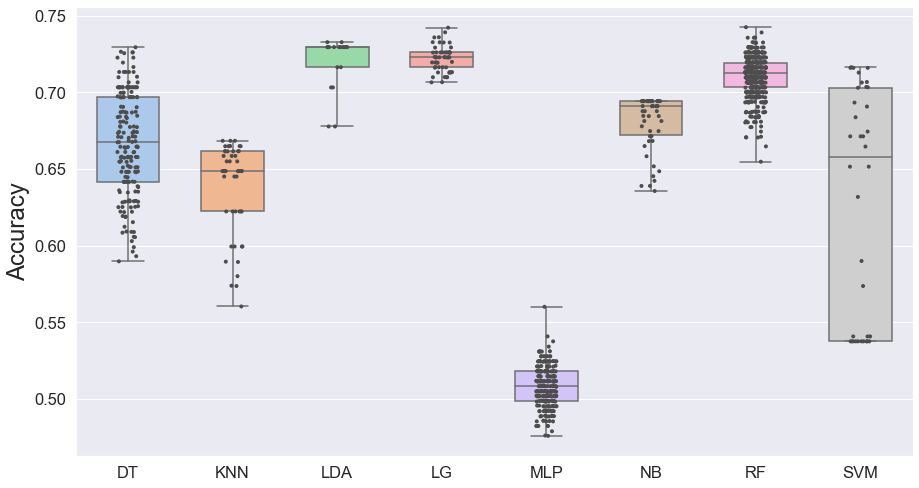

```python
#print(nb_results_df['mean_test_score'])

mean_df = pd.DataFrame({'DT': pd.DataFrame.from_dict(dt_g.cv_results_)['mean_test_score'],
                        'KNN': pd.DataFrame.from_dict(knn_g.cv_results_)['mean_test_score'],
                        'LDA': pd.DataFrame.from_dict(lda_g.cv_results_)['mean_test_score'],
                        'LG': pd.DataFrame.from_dict(lg_g.cv_results_)['mean_test_score'],
                        'MLP': pd.DataFrame.from_dict(mlp_g.cv_results_)['mean_test_score'],
                        'NB': pd.DataFrame.from_dict(nb_g.cv_results_)['mean_test_score'],
                        'RF': pd.DataFrame.from_dict(rf_g.cv_results_)['mean_test_score'],
                        'SVM': pd.DataFrame.from_dict(svm_g.cv_results_)['mean_test_score'],
                       })

sns.set(rc={'figure.figsize':(15,8.27)}, font_scale=1.5)
sns.boxplot(data=mean_df, whis=[0, 100], width=.6, palette="pastel").set_ylabel("Accuracy", fontsize=24)

# Add in points to show each observation
sns.stripplot(data=mean_df, size=4, color=".3", linewidth=0)
```

# Algorithm Comparison

Results of the algorithm comparison process, described in Section 3.2. The code produces Figure 3 in the paper.

```python
# Predict on train/test sets

dt_y_pred_train = dt_g.best_estimator_.predict(X_train)
dt_y_pred_test = dt_g.best_estimator_.predict(X_test)

knn_y_pred_train = knn_g.best_estimator_.predict(X_train)
knn_y_pred_test = knn_g.best_estimator_.predict(X_test)

lda_y_pred_train = lda_g.best_estimator_.predict(X_train)
lda_y_pred_test = lda_g.best_estimator_.predict(X_test)

lg_y_pred_train = lg_g.best_estimator_.predict(X_train)
lg_y_pred_test = lg_g.best_estimator_.predict(X_test)

mlp_y_pred_train = mlp_g.best_estimator_.predict(X_train)
mlp_y_pred_test = mlp_g.best_estimator_.predict(X_test)

nb_y_pred_train = nb_g.best_estimator_.predict(X_train)
nb_y_pred_test = nb_g.best_estimator_.predict(X_test)

rf_y_pred_train = rf_g.best_estimator_.predict(X_train)
rf_y_pred_test = rf_g.best_estimator_.predict(X_test)

svm_y_pred_train = svm_g.best_estimator_.predict(X_train)
svm_y_pred_test = svm_g.best_estimator_.predict(X_test)
```

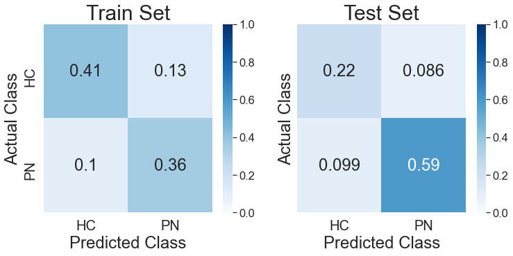

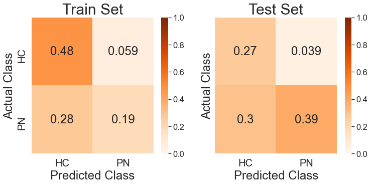

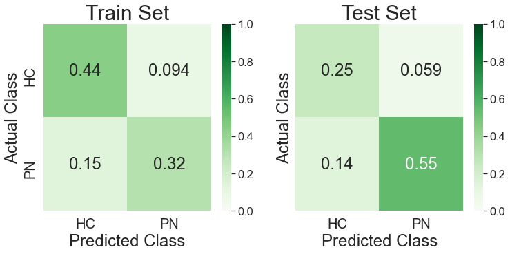

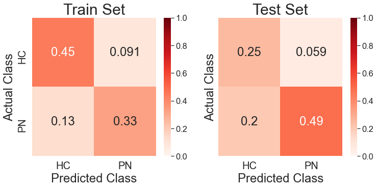

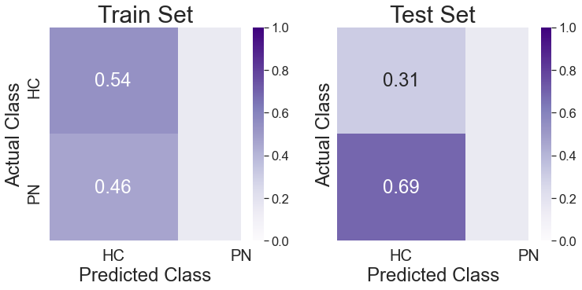

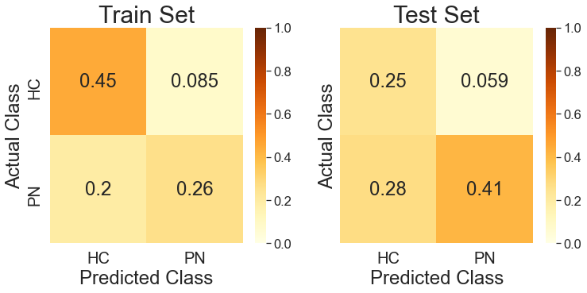

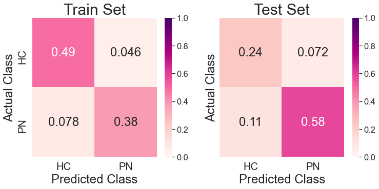

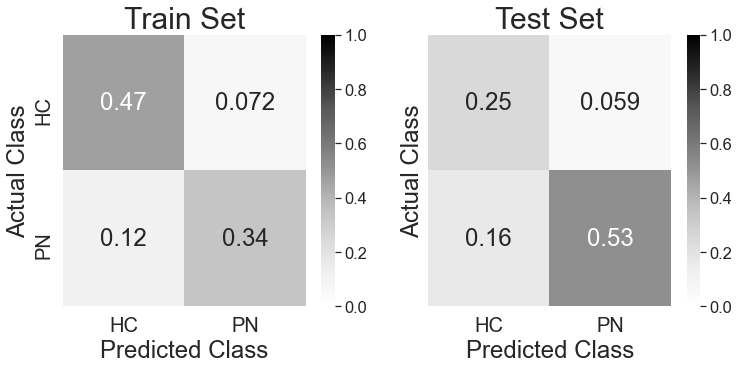

```python
# Plot confusion matrix (Figure 3, Panel A)

plot_conf(y_train, dt_y_pred_train, y_test, dt_y_pred_test, 'Descision Tree', 'Blues')
plot_conf(y_train, knn_y_pred_train, y_test, knn_y_pred_test, 'K-Nearest Neighbour', 'Oranges')
plot_conf(y_train, lda_y_pred_train, y_test, lda_y_pred_test, 'Linear Discriminant Analysis', 'Greens')
plot_conf(y_train, lg_y_pred_train, y_test, lg_y_pred_test, 'Logistic Regression', 'Reds')
plot_conf(y_train, mlp_y_pred_train, y_test, mlp_y_pred_test, 'MLP', 'Purples')
plot_conf(y_train, nb_y_pred_train, y_test, nb_y_pred_test, 'Naive Bayes', 'YlOrBr')
plot_conf(y_train, rf_y_pred_train, y_test, rf_y_pred_test, 'Random Forest', 'RdPu')
plot_conf(y_train, svm_y_pred_train, y_test, svm_y_pred_test, 'SVM', 'Greys')
```

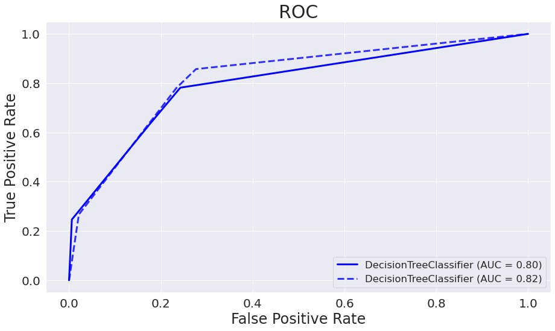

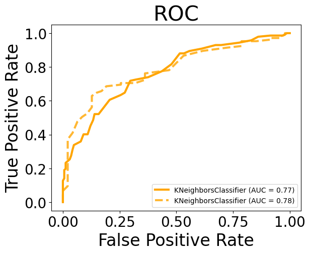

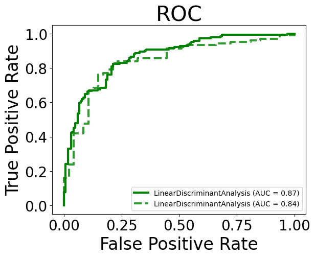

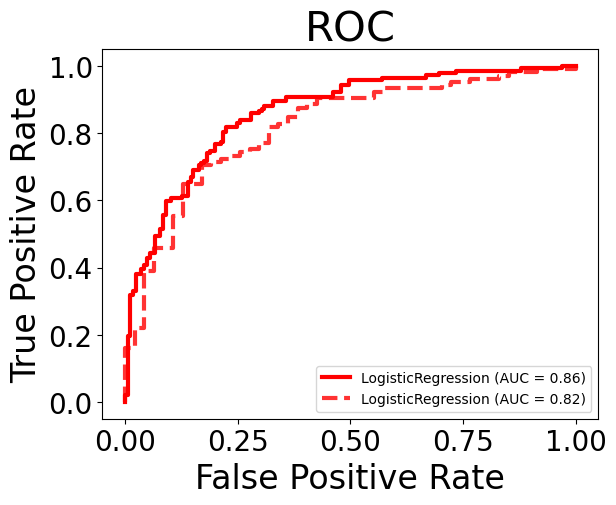

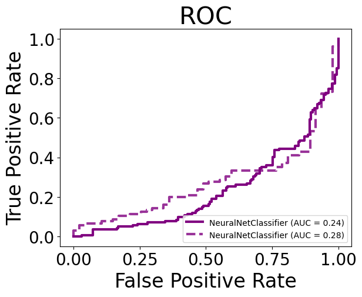

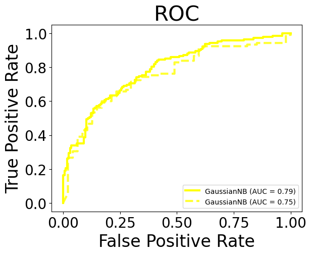

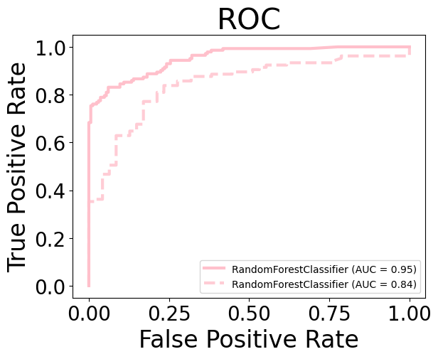

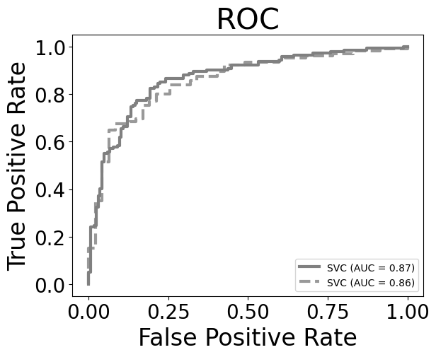

```python
# ROC AUC (Figure 3, Panel B)

plot_roc(dt_g.best_estimator_, 'Decision Tree','blue')
plot_roc(knn_g.best_estimator_, 'K-Nearest Neighbors','orange')
plot_roc(lda_g.best_estimator_, 'Linear Discriminant Analysis','green')
plot_roc(lg_g.best_estimator_, 'Logistic Regression','red')
plot_roc(mlp_g.best_estimator_, 'Multilayer Perceptron','purple')
plot_roc(nb_g.best_estimator_, 'Naive Bayes','yellow')
plot_roc(rf_g.best_estimator_, 'Random Forest','pink')
plot_roc(svm_g.best_estimator_, 'Support Vector Machine','grey')
```

```python
view_matrices(y_train, y_test, dt_y_pred_train, dt_y_pred_test, "DT")
view_matrices(y_train, y_test, knn_y_pred_train, knn_y_pred_test, "KNN")
view_matrices(y_train, y_test, lda_y_pred_train, lda_y_pred_test, "LDA")
view_matrices(y_train, y_test, lg_y_pred_train, lg_y_pred_test, "LG")
view_matrices(y_train, y_test, mlp_y_pred_train, mlp_y_pred_test, "MLP")
view_matrices(y_train, y_test, nb_y_pred_train, nb_y_pred_test, "NB")
view_matrices(y_train, y_test, rf_y_pred_train, rf_y_pred_test, "RF")
view_matrices(y_train, y_test, svm_y_pred_train, svm_y_pred_test, "SVM")
```

```
-------------------
Matrices for DT
-------------------

TRAINING

overall accuracy:  0.77
Ctrl recall:  0.78
Ctrl precision:  0.74
Ctrl F1 score:  0.76
MCI recall:  0.76
MCI precision:  0.80
MCI F1 score:  0.78

TESTING

overall accuracy:  0.82
Ctrl recall:  0.86
Ctrl precision:  0.87
Ctrl F1 score:  0.87
MCI recall:  0.72
MCI precision:  0.69
MCI F1 score:  0.71

-------------------
Matrices for KNN
-------------------

TRAINING

overall accuracy:  0.66
Ctrl recall:  0.40
Ctrl precision:  0.76
Ctrl F1 score:  0.53
MCI recall:  0.89
MCI precision:  0.63
MCI F1 score:  0.74

TESTING

```

[output cut: 136 more lines]

```
Ctrl precision:  0.83
Ctrl F1 score:  0.78
MCI recall:  0.87
MCI precision:  0.79
MCI F1 score:  0.83

TESTING

overall accuracy:  0.78
Ctrl recall:  0.76
Ctrl precision:  0.90
Ctrl F1 score:  0.82
MCI recall:  0.81
MCI precision:  0.60
MCI F1 score:  0.69
```

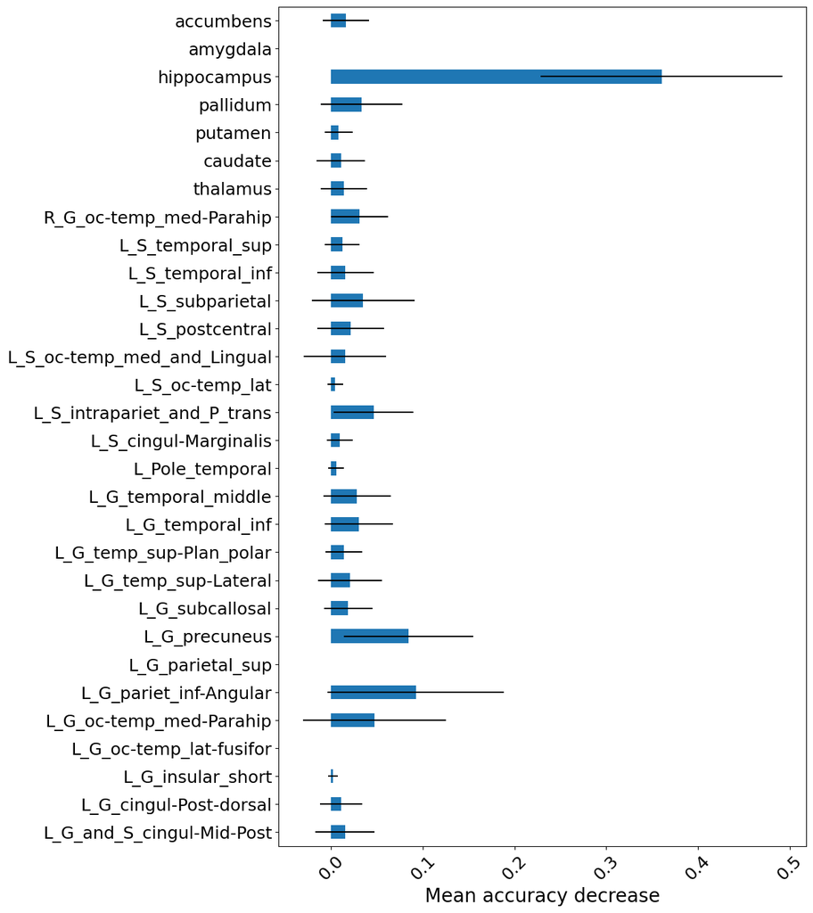

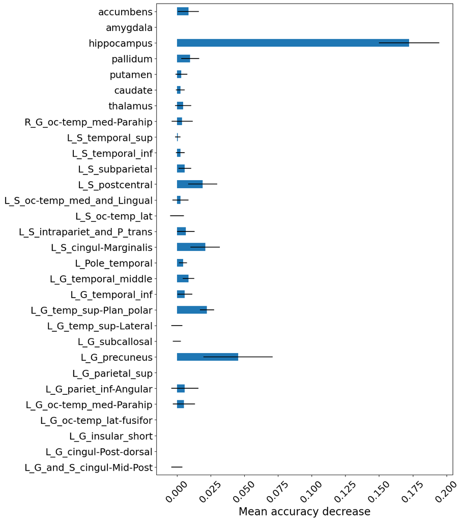

```python
# Feature importance based on mean decrease in impurity

importances = rf_g.best_estimator_.feature_importances_
std = np.std([tree.feature_importances_ for tree in rf_g.best_estimator_.estimators_], axis=0)

feature_names = list(BioFIND_data.iloc[:,0:30].columns.values.tolist())
forest_importances = pd.Series(importances, index=feature_names)

fig, ax = plt.subplots(figsize=(10,16))
forest_importances.plot.barh(xerr=std, ax=ax)
#ax.set_title("Feature importances using permutation on full model",fontsize=24)
ax.set_xlabel("Mean accuracy decrease",fontsize=20)
plt.xticks(fontsize=18, rotation=45); plt.yticks(fontsize=18)

# Feature importance based on feature permutation

from sklearn.inspection import permutation_importance

result = permutation_importance(
    rf_g.best_estimator_, X_test, y_test, n_repeats=10, random_state=42, n_jobs=2
)

forest_importances = pd.Series(result.importances_mean, index=feature_names)

fig, ax = plt.subplots(figsize=(10,16))
forest_importances.plot.barh(xerr=result.importances_std, ax=ax)
#ax.set_title("Feature importances using permutation on full model",fontsize=24)
ax.set_xlabel("Mean accuracy decrease",fontsize=20)
plt.xticks(fontsize=18, rotation=45); plt.yticks(fontsize=18)

plt.show()
```

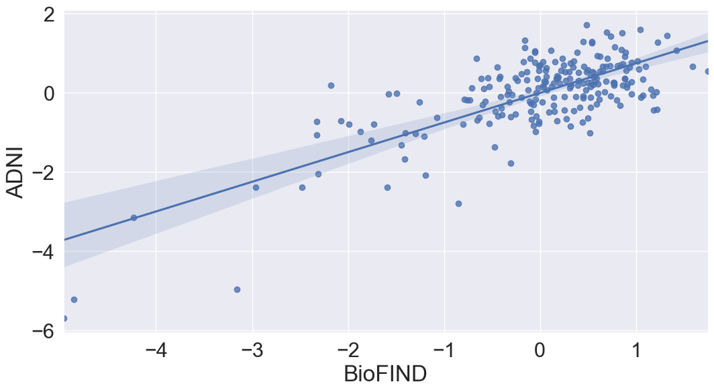

```python
# Correlation between Rs values

Rs_data = pd.read_csv('Rs.csv') # this file is avaliable in the submitted folder

sns.set(color_codes=True, font_scale=2)
lm = sns.lmplot(x="BioFIND", y="ADNI", data=Rs_data, height=6, aspect=1.8)
plt.show()
```